# Exploratory data analyses and data preparation report - Knotweed Tarping Survey (Martin *et al.*, 2023)

## 4.3 - Multivariate relationships

### 4.3.1 - Correlation among variables and multicollinearity

To investigate potential correlations and collinearity among our variables, we started by computing a **correlation matrix** of the data. As most of our factors were either ordered factors (i.e. ordinal variables) or binary factors (i.e. boolean), we could use them in a correlation matrix. To do that however, computations were based on *Spearman*’s rank correlation coefficients.  
To avoid giving too much weight to tarping experiments made by the same operators (that could be autocorrelated), we removed them from the data to compute correlations: their influence was accounted for in further analyses (only when modelling diagnostics indicated autocorrelation) by the use of **mixed-effect models**.

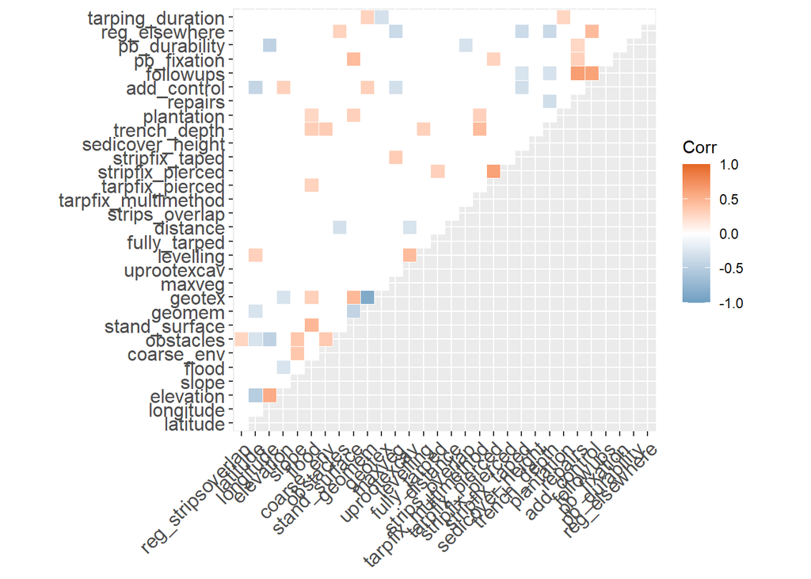

**Figure 4.5.** Correlation matrix displaying *Spearman*’s $\rho$ for the numeric variables and ordered factors of the *regrowth at strips overlap* dataset. Only significant correlations are displayed (with $\alpha$ = 0.05)

At this stage and in accordance with the hierarchy of hypotheses we would like to test for the *reg_stripsoverlap* variable, we decided to drop the following variables: *geotex*, *maxveg*, *uprootexcav* and *flood*.

### 4.3.2 - Relationships among explanatory variables

To further study distributions and bivariate correlations, we decided to plot every numeric predictor against each others. It gives us the possibility to start investigating potential **multivariate outliers**.

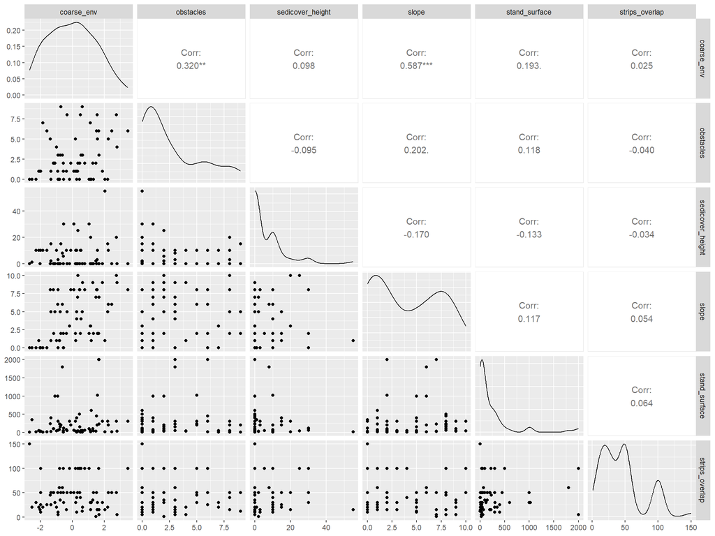

**Figure 4.6.** Bivariate relationship among all numeric potential explanatory variables

This figure confirms that most variables are far from being normally distributed but that’s not necessarily a problem. If many scatterplots appear relatively compact and consistent, all highly skewed variables (i.e. *stand_surface*, *sedicover_height*, and *strips_overlap*) tend to produce what seem to be multivariate outliers that could become potentially problematic for modelling. In case it happens, transforming these variables may be useful.

### 4.3.3 - Relationships between *reg_stripsoverlap* and its potential explanatory variables

Since *reg_stripsoverlap* will be modelled using logistic regressions, it is very important to ensure the respect of the **linearity assumption** between the outcome on the *logit scale* and each numeric predictor, for instance using Box-Tidwell tests or scatterplots. The main issue here is to get the values of the response variable on the logit scale. To do so, we have to build a logistic model incorporating all potential predictors to extract expected probabilities. A drawback from this approach is that the toy model can easily be misspecified in the process: for that reason, we actually checked this assumption iteratively for each *a priori* candidate model built for analyses (the scatterplots displayed below only serve to illustrate what transformations were actually applied to linearize relationships).

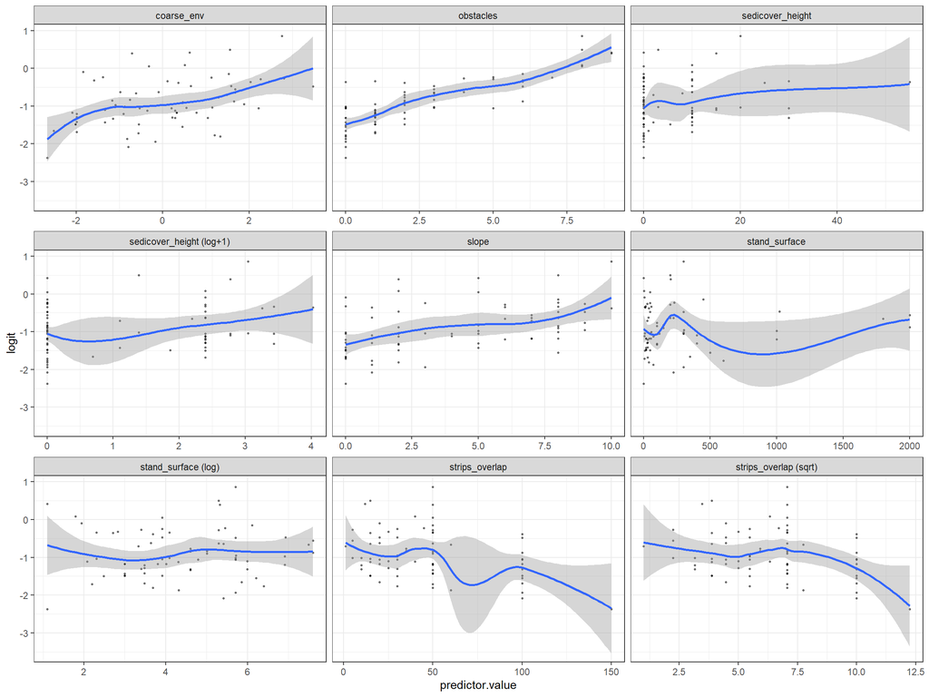

**Figure 4.7.** Bivariate scatterplot between of the *reg_stripsoverlap* variable on the *logit scale* and each potential numeric predictor

More general scatterplots can further be used to ensure the absence of bivariate **(quasi-)perfect separation** between a predictor and the response variable, which is highly problematic for logistic models fitted using Maximum Likelihood (Allison, 2004).

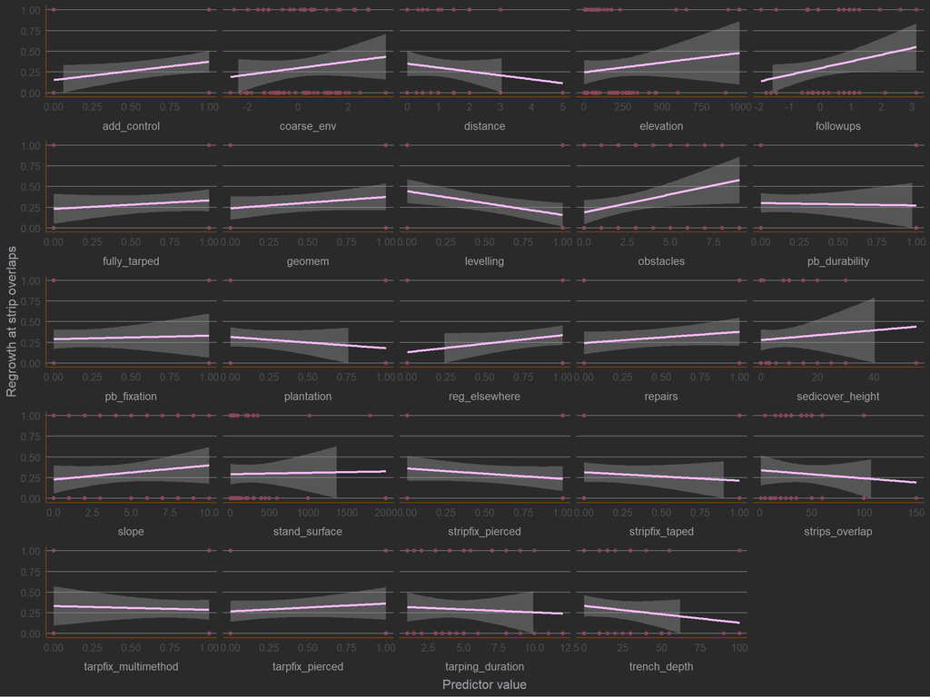

**Figure 4.8.** Multivariate representation of *reg_stripsoverlap* against each potential explanatory variable

There is no apparent sign of bivariate (quasi-)perfect separation, so regular logistic models can be used as well as multimodel inference.

### 4.3.4 - Interactions among variables

Finally and similarly as for other response variables, we would have liked to further investigate potentially meaningful **interactions** among our variables using co-plots (i.e. conditioning plots). Unfortunately, as *reg_stripsoverlap* contains only 22 successes (i.e. *n*<sub>1</sub> = 22 and *n*<sub>0</sub> = 52), our sample will not enable us to model interactions because it would require estimating three parameters, which is too many for such a small sample (Harrell, 2015).

# 5 - References

- Allison P.D., 2004. *Convergence Problems in Logistic Regression*. In Altman M., Gill J. and McDonald M.P. (eds.), *Numerical Issues in Statistical Computing for the Social Scientist*. John Wiley & Sons, Hoboken: USA (pp. 238-252).
- Bolker B., 2007. *Ecological Models and Data in R*. Princeton University Press, Princeton: USA (408 p.).
- Field A., 2009. *Discovering statistics using SPSS*. SAGE Publications Ltd, London: The United Kingdom (952 p.).
- Fox J. and Monette G., 1992. Generalized Collinearity Diagnostics. *Journal of the American Statistical Association*, vol. 87: 178-183. doi: 10.2307/2290467
- Fox J., 2008. *Applied Regression Analysis and Generalized Linear Models, 2nd edition*. SAGE Publishing, Newbury Park: USA (688 p.).
- Gravetter F. and Wallnau,L., 2014. *Essentials of statistics for the behavioral sciences (8th ed.)*. Cengage Learning, Boston: USA (648 p.).
- Harrell F., 2015. *Regression Modeling Strategies. With Applications to Linear Models, Logistic and Ordinal Regression, and Survival Analysis*. Springer Nature, Cham: Switzerland (582 p.).
- Martin FM., Dommanget F., Janssen P. Spiegelberger T., Viguier C. and Evette A., 2019. Could knotweeds invade mountains in their introduced range? An analysis of patches dynamics along an elevational gradient. *Alpine Botany*, vol. 129: 33–42. doi: 10.1007/s00035-018-0214-5
- Montgomery D.C. and Peck E.A., 1992. *Introduction to Linear Regression Analysis*. John Wiley & Sons, Hoboken: USA (544 p.).
- Stekhoven DJ and Bühlmann P., 2012. MissForest–non-parametric missing value imputation for mixed-type data. *Bioinformatics*, vol. 28:112-118. doi: 10.1093/bioinformatics/btr597
- Zuur A.F., Ieno E.N. and Elphick C.S., 2010. A protocol for data exploration to avoid common statistical problems. *Methods in Ecology and Evolution*, vol. 1: 3-14. doi: 10.1111/j.2041-210X.2009.00001.x